# Atividade em grupo — Predição conformal

- Mostrar o código
- Esconder o código
- Ver o código fonte

Laboratório de Estatística Aplicada — DEs/UFSCar

Autores

Arthur Pereira Gon (RA 811464)

Isabella Viana Bambirra (RA 811753)

Data de Publicação

11/10/2026

**NotaInstruções**

- **Prazo:** 23/10/2026, por e-mail.
- **Entrega:** este arquivo `.qmd` preenchido **e** o `.html` gerado por ele (botão *Render* no RStudio).
- O código já está pronto. O trabalho do grupo é **preencher os RAs** dos integrantes na Seção 1 (a base de dados é definida automaticamente a partir deles), **rodar** tudo e **responder** às tarefas nos blocos marcados com **Resposta**.
- Respostas curtas e diretas (2 a 5 frases por item), sempre **no contexto dos dados** do grupo.
- Pacotes necessários: `ISLR2`, `ranger`, `dplyr`, `tidyr`, `ggplot2`. Se faltar algum, rode uma vez no console `install.packages(c("ISLR2", "ranger", "dplyr", "tidyr", "ggplot2"))`.
- A Seção 7 é **opcional** e vale ponto extra.

**DicaResumo do grupo**

**Base 2: Bikeshare** (RAs 811464 + 811753), com a resposta `bikers` (bicicletas alugadas por hora em Washington, D.C.) e intervalos de 90%.

|  | Principal resultado |
| --- | --- |
| Dados | Resposta assimétrica e muito heteroscedástica: DP de 24 na madrugada contra 150 no pico (16-19h). |
| Experimento | Os três métodos têm cobertura de ~89-90%; o Conformal (floresta) gera intervalos ~30% mais curtos que o Conformal (lm). |
| 50 repetições | Cobertura média conformal de ~90%, como prevê a teoria; o clássico fica quase sempre um pouco abaixo (~89%). |
| Subgrupos | A garantia é só marginal: ~100% na madrugada e ~77% no pico. |
| Seção 7 (opcional) | O escore normalizado reduz o comprimento médio em ~24% e melhora o pico (76% → 82%). |
| Seção 8 (extra) | Mondrian CP: ~90% em **todas** as faixas, com intervalos mais curtos em média que os da calibração global. |

As respostas estão nos blocos destacados **Resposta**. O código dos experimentos pode ser expandido em “Código” (ou todo de uma vez no botão **Código**, no topo da página).

# 1 Configuração

**Código**

```r
library(dplyr)
library(tidyr)
library(ggplot2)
library(ranger)
```

Cada grupo trabalha com uma das quatro bases, definida pelos RAs dos integrantes:
$$\text{base} = \Big(\textstyle\sum_{j} \text{RA}_j\Big) \bmod 4 + 1.$$
Altere **apenas** a linha `RAs <- ...` abaixo, com os RAs de **todos** os integrantes (se o grupo for uma dupla, apague um `NA`; se for individual, deixe só o seu RA).

**Código**

```r
RAs <- c(811464, 811753)   # Arthur Pereira Gon, Isabella Viana Bambirra

if (anyNA(RAs)) stop("Preencha os RAs dos integrantes no chunk 'grupo'.")
GRUPO <- sum(as.numeric(RAs)) %% 4 + 1
```

**Código**

```r
# Cada grupo trabalha com uma base diferente. Para cada uma definimos:
#   resposta : variável a ser predita
#   excluir  : variáveis que NÃO podem entrar como covariáveis
#   subgrupo : partição usada na Seção 6 (cobertura por subgrupo)
configs <- list(
  "1" = list(
    descricao = "Salário anual (em milhares de US$) de trabalhadores homens da região do Atlântico Médio (EUA)",
    carregar  = function() ISLR2::Wage,
    resposta  = "wage",
    excluir   = c("logwage", "region"),
    subgrupo  = function(d) d$education,
    nome_sub  = "Escolaridade"
  ),
  "2" = list(
    descricao = "Número de bicicletas alugadas por hora em Washington, D.C.",
    carregar  = function() {
      d <- ISLR2::Bikeshare
      # a categoria "heavy rain/snow" tem uma única observação: juntamos com "light rain/snow"
      levels(d$weathersit)[levels(d$weathersit) == "heavy rain/snow"] <- "light rain/snow"
      d
    },
    resposta  = "bikers",
    excluir   = c("casual", "registered"),
    subgrupo  = function(d) {
      h <- as.numeric(as.character(d$hr))
      cut(h, breaks = c(-1, 5, 15, 19, 23),
          labels = c("madrugada (0-5h)", "dia (6-15h)", "pico (16-19h)", "noite (20-23h)"))
    },
    nome_sub  = "Faixa horária"
  ),
  "3" = list(
    descricao = "Número de candidatos (inscrições) recebidos por universidades dos EUA",
    carregar  = function() ISLR2::College,
    resposta  = "Apps",
    excluir   = c("Accept", "Enroll"),
    subgrupo  = function(d) factor(d$Private, levels = c("No", "Yes"),
                                  labels = c("Pública", "Privada")),
    nome_sub  = "Tipo de instituição"
  ),
  "4" = list(
    descricao = "Preço (em US$) de diamantes (amostra de 5000 diamantes)",
    carregar  = function() {
      set.seed(2026)
      d <- as.data.frame(ggplot2::diamonds)
      d <- d[sample(nrow(d), 5000), ]
      # fatores ordenados viram fatores comuns (facilita a leitura do lm)
      d$cut <- factor(d$cut, ordered = FALSE)
      d$color <- factor(d$color, ordered = FALSE)
      d$clarity <- factor(d$clarity, ordered = FALSE)
      d
    },
    resposta  = "price",
    excluir   = character(0),
    subgrupo  = function(d) cut(d$carat, breaks = c(0, 0.5, 1, Inf), right = FALSE,
                                labels = c("< 0,5 quilate", "0,5 a 1 quilate", ">= 1 quilate")),
    nome_sub  = "Tamanho (quilates)"
  )
)

cfg <- configs[[as.character(GRUPO)]]

bruto <- as.data.frame(cfg$carregar())

# Base de modelagem: resposta (renomeada para y) + covariáveis permitidas
covariaveis <- setdiff(names(bruto), c(cfg$resposta, cfg$excluir))
dados <- data.frame(y = bruto[[cfg$resposta]], bruto[, covariaveis])

# Subgrupo de cada observação (NÃO entra no modelo, serve só para avaliar)
subgrupo <- cfg$subgrupo(bruto)

# Nível de descobertura: intervalos de 90%
alpha <- 0.10
```

**RAs:** 811464, 811753 → (soma) mod 4 + 1 = **base 2**.

**Base 2:** Número de bicicletas alugadas por hora em Washington, D.C.. São 8645 observações; a resposta é bikers e as covariáveis usadas são: season, mnth, day, hr, holiday, weekday, workingday, weathersit, temp, atemp, hum, windspeed.

## 1.1 Funções auxiliares

As funções abaixo implementam o que vimos em aula. **Leia** cada uma antes de seguir; não é preciso alterá-las.

**Código**

```r
# Separa os índices 1..n em treino / calibração / teste (conjuntos disjuntos)
dividir_dados <- function(n, props = c(treino = 0.4, calib = 0.3, teste = 0.3)) {
  idx <- sample(seq_len(n))
  n_tr <- floor(props[1] * n)
  n_ca <- floor(props[2] * n)
  list(treino = idx[1:n_tr],
       calib  = idx[(n_tr + 1):(n_tr + n_ca)],
       teste  = idx[(n_tr + n_ca + 1):n])
}

# Quantil conformal: R_(k), com k = ceiling((1 - alpha) * (n + 1))
quantil_conformal <- function(escores, alpha) {
  n <- length(escores)
  k <- ceiling((1 - alpha) * (n + 1))
  if (k > n) return(Inf)          # calibração pequena demais para esse alpha
  sort(escores)[k]
}

# Cobertura empírica e comprimento médio de um conjunto de intervalos
avaliar <- function(y, inf, sup) {
  c(cobertura = mean(y >= inf & y <= sup),
    comprimento = mean(sup - inf))
}

# Gráfico dos intervalos para (no máximo) 100 observações de teste,
# ordenadas pelo valor predito
grafico_intervalos <- function(y, y_hat, inf, sup, titulo, max_n = 100) {
  m <- avaliar(y, inf, sup)
  tibble(y, y_hat, inf, sup) |>
    slice_head(n = max_n) |>
    arrange(y_hat) |>
    mutate(ordem = row_number(),
           dentro = ifelse(y >= inf & y <= sup, "dentro", "fora")) |>
    ggplot(aes(x = ordem)) +
    geom_errorbar(aes(ymin = inf, ymax = sup), color = "grey55", width = 0) +
    geom_point(aes(y = y_hat), color = "#0067B1", size = 1) +
    geom_point(aes(y = y, color = dentro), size = 1.2) +
    scale_color_manual(values = c(dentro = "black", fora = "#B42828")) +
    labs(x = "observações de teste (ordenadas pela predição)", y = cfg$resposta,
         color = "Valor observado", title = titulo,
         caption = "Pontos azuis: valor predito. Barras cinza: intervalo de predição.",
         subtitle = sprintf("Cobertura empírica = %.1f%%  |  Comprimento médio = %.1f",
                            100 * m["cobertura"], m["comprimento"])) +
    theme_bw() +
    theme(legend.position = "bottom")
}

# Um experimento completo: divide, ajusta os modelos e devolve os intervalos
# dos três métodos para o conjunto de teste
experimento <- function(dados, alpha) {
  sp <- dividir_dados(nrow(dados))
  tr <- dados[sp$treino, ]; ca <- dados[sp$calib, ]; te <- dados[sp$teste, ]

  lin <- lm(y ~ ., data = tr)
  rf  <- ranger(y ~ ., data = tr, num.trees = 200)

  # (a) intervalo clássico da regressão linear
  cl <- predict(lin, newdata = te, interval = "prediction", level = 1 - alpha)

  # (b) split conformal com regressão linear
  r_lin  <- quantil_conformal(abs(ca$y - predict(lin, newdata = ca)), alpha)
  yh_lin <- predict(lin, newdata = te)

  # (c) split conformal com floresta aleatória
  r_rf  <- quantil_conformal(abs(ca$y - predict(rf, data = ca)$predictions), alpha)
  yh_rf <- predict(rf, data = te)$predictions

  bind_rows(
    tibble(id = sp$teste, y = te$y, metodo = "Clássico (lm)",
           inf = cl[, "lwr"], sup = cl[, "upr"]),
    tibble(id = sp$teste, y = te$y, metodo = "Conformal (lm)",
           inf = yh_lin - r_lin, sup = yh_lin + r_lin),
    tibble(id = sp$teste, y = te$y, metodo = "Conformal (floresta)",
           inf = yh_rf - r_rf, sup = yh_rf + r_rf)
  )
}
```

# 2 Exploração dos dados

**Código**

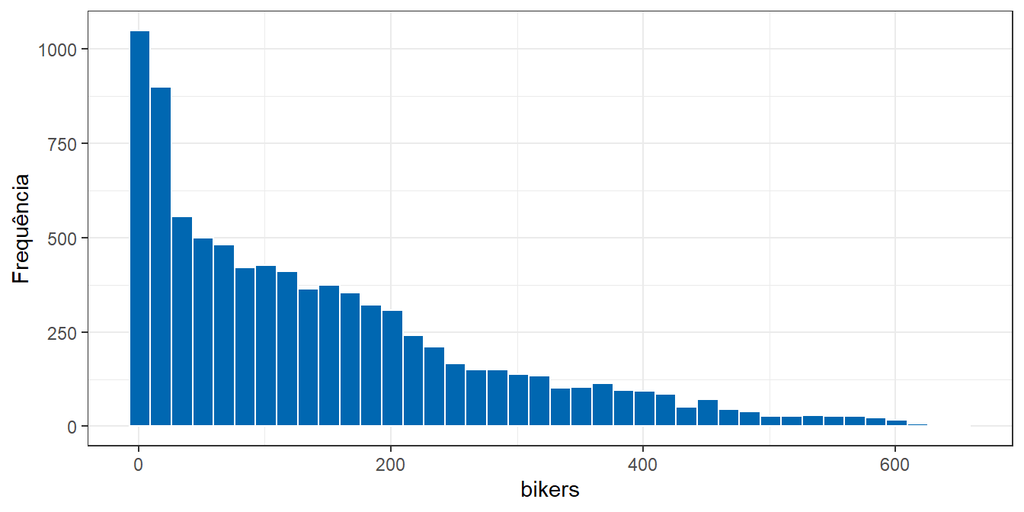

```r
ggplot(dados, aes(x = y)) +
  geom_histogram(bins = 40, fill = "#0067B1", color = "white") +
  labs(x = cfg$resposta, y = "Frequência") +
  theme_bw()
```

**Código**

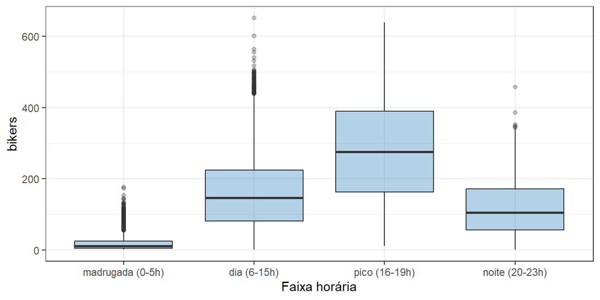

```r
tibble(y = dados$y, subgrupo = subgrupo) |>
  ggplot(aes(x = subgrupo, y = y)) +
  geom_boxplot(fill = "#0067B1", alpha = 0.3) +
  labs(x = cfg$nome_sub, y = cfg$resposta) +
  theme_bw()
```

**Código**

```r
tibble(y = dados$y, subgrupo = subgrupo) |>
  group_by(subgrupo) |>
  summarise(n = n(), media = mean(y), desvio_padrao = sd(y)) |>
  knitr::kable(digits = 1, col.names = c(cfg$nome_sub, "n", "Média", "Desvio-padrão"))
```

| Faixa horária | n | Média | Desvio-padrão |
| --- | --- | --- | --- |
| madrugada (0-5h) | 2105 | 20.0 | 24.2 |
| dia (6-15h) | 3632 | 168.1 | 114.6 |
| pico (16-19h) | 1456 | 285.7 | 150.0 |
| noite (20-23h) | 1452 | 120.2 | 76.8 |

**ImportanteTarefa 1**

1. Descreva a distribuição da resposta: é simétrica? Há valores extremos?
2. A variabilidade da resposta é parecida entre os subgrupos? Qual subgrupo é o mais variável?
3. As variáveis listadas em `excluir` na configuração do seu grupo foram retiradas das covariáveis. Por que seria um erro usá-las para predizer a resposta?

**Resposta:**

1. A distribuição do número de bicicletas alugadas por hora é claramente assimétrica à direita: a mediana é 109 e a média é 144, com muitas horas de demanda quase nula (653 horas com no máximo 5 aluguéis) e uma cauda longa até 651 bicicletas/hora. Não há valores impossíveis, mas os valores acima de 450 (cerca de 4% das horas, concentrados às 17h-18h e às 8h, os horários de ida e volta do trabalho) são extremos em relação ao restante. Como é uma contagem, a resposta é limitada inferiormente por zero, o que reforça a assimetria.
2. Não: a variabilidade muda muito entre as faixas horárias e cresce junto com a média. O desvio-padrão vai de 24 bicicletas na madrugada (0-5h) a 77 à noite, 115 durante o dia e 150 no horário de pico (16-19h), que é o subgrupo mais variável. Ou seja, a dispersão no pico é cerca de seis vezes a da madrugada.
3. As variáveis `casual` e `registered` são o número de aluguéis de usuários avulsos e de usuários cadastrados, e a resposta é exatamente a soma delas (`bikers = casual + registered`). Usá-las seria vazamento de informação (*data leakage*): o modelo “preveria” a resposta com erro praticamente zero, mas elas só são conhecidas depois que a hora termina, justamente quando já sabemos o total. Os intervalos resultantes seriam artificialmente curtos e inúteis para prever a demanda de uma hora futura.

# 3 Um experimento: clássico vs. conformal

Separamos os dados em treino (40%), calibração (30%) e teste (30%), e construímos intervalos de 90% de três formas:

- **Clássico (lm):** intervalo de predição da regressão linear, que supõe erros normais, independentes e com variância constante;
- **Conformal (lm):** split conformal com escore $R_i = |Y_i - \hat\mu(X_i)|$ e $\hat\mu$ = regressão linear;
- **Conformal (floresta):** o mesmo, com $\hat\mu$ = floresta aleatória.

**Código**

```r
set.seed(123)
res <- experimento(dados, alpha)

res |>
  group_by(metodo) |>
  summarise(cobertura = mean(y >= inf & y <= sup),
            comprimento = mean(sup - inf)) |>
  knitr::kable(digits = 3, col.names = c("Método", "Cobertura empírica", "Comprimento médio"))
```

| Método | Cobertura empírica | Comprimento médio |
| --- | --- | --- |
| Clássico (lm) | 0.891 | 249.122 |
| Conformal (floresta) | 0.890 | 179.725 |
| Conformal (lm) | 0.897 | 256.304 |

**Código**

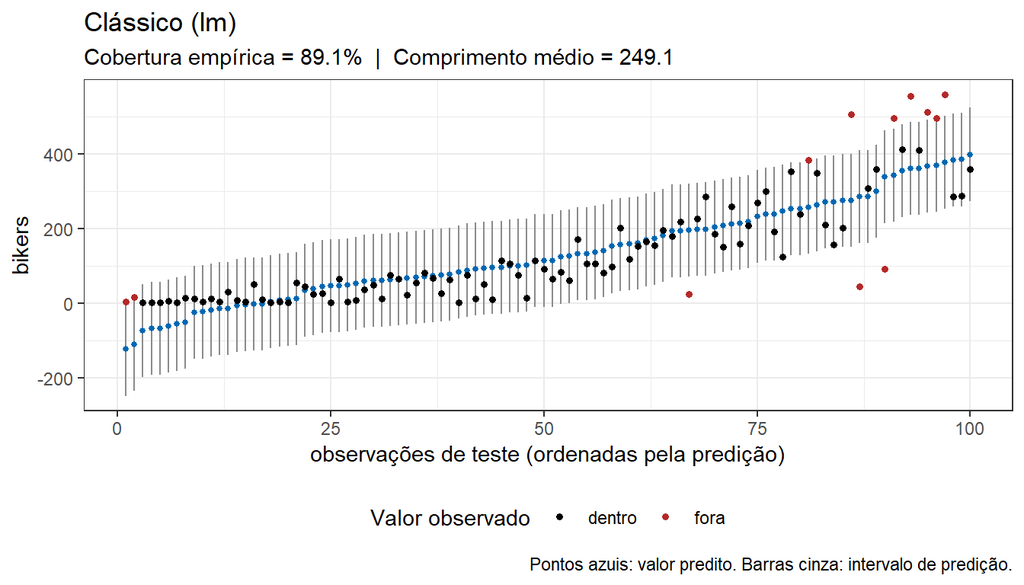

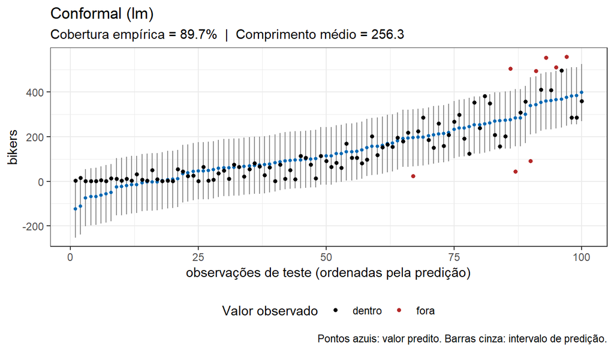

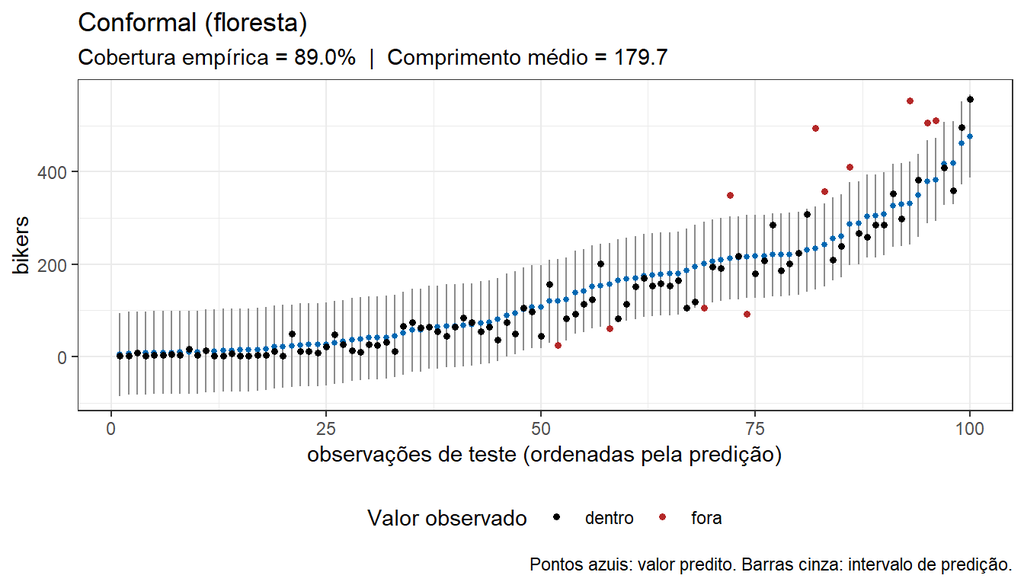

```r
for (m in unique(res$metodo)) {
  r <- filter(res, metodo == m)
  yh <- (r$inf + r$sup) / 2   # centro do intervalo = valor predito
  print(grafico_intervalos(r$y, yh, r$inf, r$sup, titulo = m))
}
```

Para avaliar as suposições do intervalo clássico, olhamos os resíduos da regressão linear no treino:

**Código**

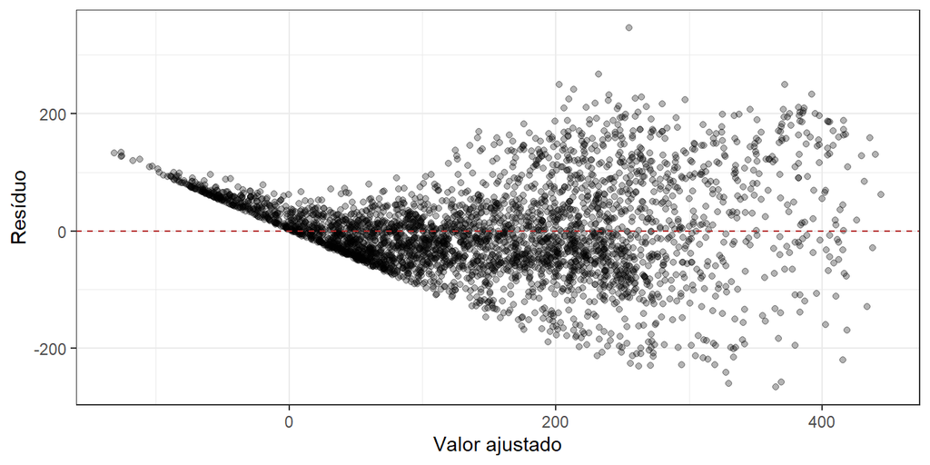

```r
set.seed(123)
sp  <- dividir_dados(nrow(dados))
lin <- lm(y ~ ., data = dados[sp$treino, ])
tibble(ajustado = fitted(lin), residuo = resid(lin)) |>
  ggplot(aes(ajustado, residuo)) +
  geom_point(alpha = 0.3) +
  geom_hline(yintercept = 0, linetype = 2, color = "#B42828") +
  labs(x = "Valor ajustado", y = "Resíduo") +
  theme_bw()
```

**ImportanteTarefa 2**

1. Qual método ficou mais próximo da cobertura nominal de 90%? Algum ficou claramente abaixo ou acima?
2. Pelo gráfico de resíduos, as suposições do intervalo clássico parecem razoáveis? Qual delas parece mais violada?
3. Compare os comprimentos médios de “Conformal (lm)” e “Conformal (floresta)”. Qual produziu intervalos mais curtos? O que isso indica sobre a qualidade preditiva de cada modelo, já que ambos têm a mesma garantia de cobertura?

# 4 A cobertura varia de experimento para experimento

O resultado da Seção 3 depende de **uma** divisão aleatória dos dados. Agora repetimos o experimento 50 vezes, sorteando novas divisões a cada vez (pode levar cerca de um minuto; na base 2, Bikeshare, que é a maior, alguns minutos).

**Código**

```r
B <- 50
set.seed(2026)
reps <- lapply(seq_len(B), function(b) experimento(dados, alpha) |> mutate(rep = b)) |>
  bind_rows()

resumo_rep <- reps |>
  group_by(rep, metodo) |>
  summarise(cobertura = mean(y >= inf & y <= sup),
            comprimento = mean(sup - inf), .groups = "drop")
```

**Código**

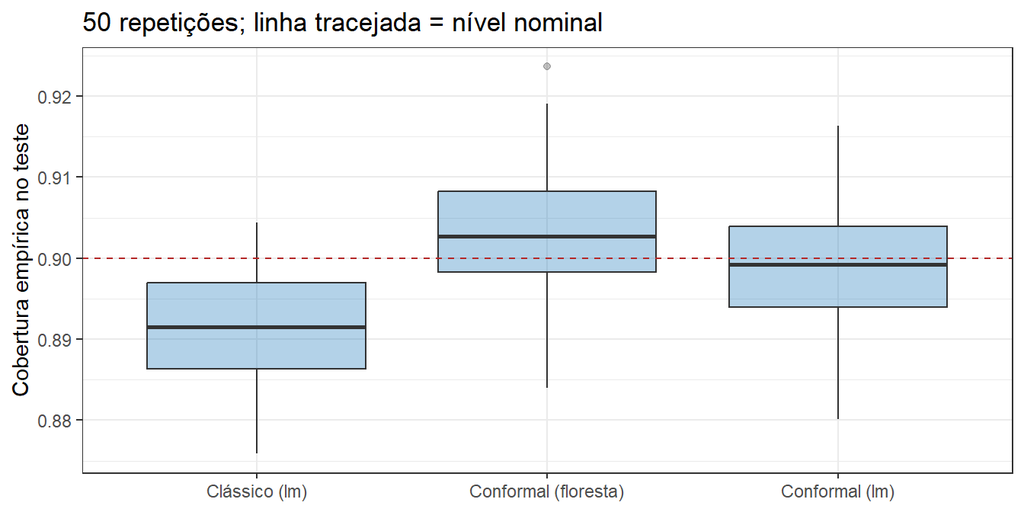

```r
ggplot(resumo_rep, aes(x = metodo, y = cobertura)) +
  geom_boxplot(fill = "#0067B1", alpha = 0.3) +
  geom_hline(yintercept = 1 - alpha, linetype = 2, color = "#B42828") +
  labs(x = NULL, y = "Cobertura empírica no teste",
       title = sprintf("%d repetições; linha tracejada = nível nominal", B)) +
  theme_bw()
```

**Código**

```r
resumo_rep |>
  group_by(metodo) |>
  summarise(cob_media = mean(cobertura), cob_min = min(cobertura),
            cob_max = max(cobertura), comp_medio = mean(comprimento)) |>
  knitr::kable(digits = 3, col.names = c("Método", "Cobertura média", "Mínima",
                                         "Máxima", "Comprimento médio"))
```

| Método | Cobertura média | Mínima | Máxima | Comprimento médio |
| --- | --- | --- | --- | --- |
| Clássico (lm) | 0.891 | 0.876 | 0.904 | 250.442 |
| Conformal (floresta) | 0.903 | 0.884 | 0.924 | 182.230 |
| Conformal (lm) | 0.899 | 0.880 | 0.916 | 259.004 |

**ImportanteTarefa 3**

1. Por que a cobertura empírica muda de uma repetição para outra, mesmo com o mesmo método e o mesmo $\alpha$?
2. A garantia vista em aula, $P(Y_{n+1} \in C(X_{n+1})) \geq 1-\alpha$, é sobre **uma** repetição ou sobre a **média** de muitas? A cobertura média dos métodos conformais está de acordo com ela?
3. O intervalo clássico ficou sistematicamente acima ou abaixo de 90%? Relacione com a sua resposta da Tarefa 2(b).

# 5 Cobertura por subgrupo

A garantia da predição conformal é **marginal**: vale na média sobre toda a população. Vamos verificar o que acontece dentro de cada subgrupo, usando todas as repetições para reduzir o ruído.

**Código**

```r
reps <- reps |> mutate(subgrupo = subgrupo[id])

cob_sub <- reps |>
  group_by(metodo, subgrupo) |>
  summarise(cobertura = mean(y >= inf & y <= sup),
            comprimento = mean(sup - inf), .groups = "drop")

cob_sub |>
  select(-comprimento) |>
  pivot_wider(names_from = metodo, values_from = cobertura) |>
  rename(!!cfg$nome_sub := subgrupo) |>
  knitr::kable(digits = 3)
```

| Faixa horária | Clássico (lm) | Conformal (floresta) | Conformal (lm) |
| --- | --- | --- | --- |
| madrugada (0-5h) | 0.993 | 0.999 | 0.995 |
| dia (6-15h) | 0.844 | 0.872 | 0.855 |
| pico (16-19h) | 0.757 | 0.771 | 0.773 |
| noite (20-23h) | 0.996 | 0.970 | 0.996 |

**Código**

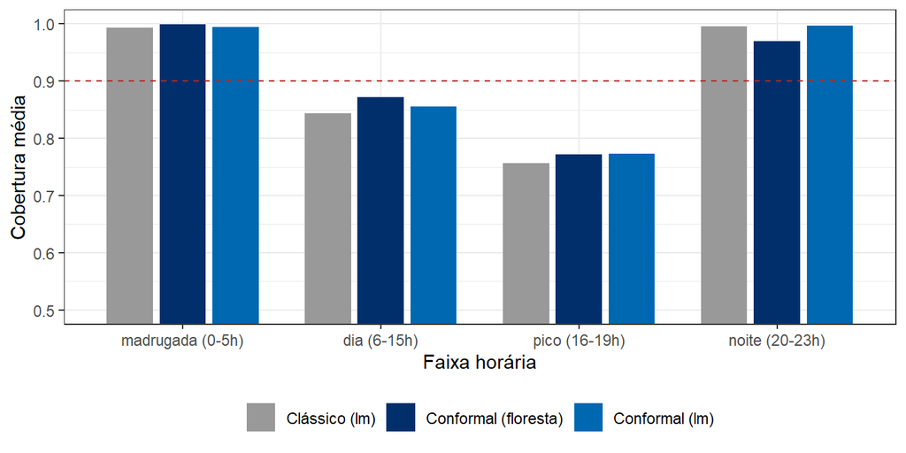

```r
ggplot(cob_sub, aes(x = subgrupo, y = cobertura, fill = metodo)) +
  geom_col(position = position_dodge(width = 0.8), width = 0.7) +
  geom_hline(yintercept = 1 - alpha, linetype = 2, color = "#B42828") +
  coord_cartesian(ylim = c(0.5, 1)) +
  scale_fill_manual(values = c("grey60", "#002F6C", "#0067B1")) +
  labs(x = cfg$nome_sub, y = "Cobertura média", fill = NULL) +
  theme_bw() +
  theme(legend.position = "bottom")
```

**ImportanteTarefa 4**

1. Em quais subgrupos a cobertura dos métodos conformais fica abaixo de 90%? E acima?
2. Explique o padrão usando o que você observou na Tarefa 1(b). Dica: o intervalo conformal com resíduo absoluto tem o **mesmo comprimento** para todas as observações.
3. Isso contradiz a garantia da predição conformal? Justifique.
4. Dê um exemplo concreto, no contexto dos seus dados, de alguém que seria prejudicado por usar esses intervalos sem olhar a cobertura por subgrupo.

**Resposta:**

1. Os métodos conformais ficam abaixo de 90% no “dia (6-15h)” (85% a 87%) e, sobretudo, no “pico (16-19h)” (~77%). Ficam acima na “madrugada (0-5h)” (~100%) e na “noite (20-23h)” (97% a 100%). Em resumo, a cobertura global de 90% é uma média de faixas com cobertura muito alta e de faixas com cobertura bem abaixo do nominal.
2. O intervalo conformal com resíduo absoluto tem o mesmo comprimento, $2\hat r_\alpha$, em todas as horas (cerca de 180 bicicletas na floresta), mas a Tarefa 1(b) mostrou que a variabilidade da demanda é muito diferente entre as faixas. Na madrugada (DP ≈ 24) esse intervalo é largo demais e quase sempre cobre o valor observado. No pico (DP ≈ 150), os erros de predição são bem maiores e o mesmo intervalo é estreito demais, então muitas horas ficam de fora. O quantil $\hat r_\alpha$ fica “no meio” e equilibra as faixas só na média.
3. Não contradiz. A garantia vista em aula é **marginal**: $P(Y_{n+1} \in C(X_{n+1})) \geq 1-\alpha$ vale na média sobre toda a população de horas, e de fato a cobertura global ficou em ~90%. Ela não promete cobertura condicional, $P(Y_{n+1} \in C(X_{n+1}) \mid X_{n+1} = x) \geq 1-\alpha$, nem cobertura dentro de cada subgrupo. Esse é exatamente o exemplo das regiões A/B dos slides: 99% em um grupo e 81% no outro resultam em 90% na média.
4. Considere o responsável pela redistribuição de bicicletas entre as estações em Washington, que usa o limite superior do intervalo de 90% para decidir quantas bicicletas deixar disponíveis. No horário de pico da tarde (16-19h), quando mais gente volta do trabalho, a demanda real fica fora do intervalo em cerca de 1 a cada 4 horas, e não em 1 a cada 10. Quase todos esses erros são para cima: em ~20% das horas de pico a demanda **supera** o limite superior (contra ~3% abaixo do limite inferior; ver Seção 8). O resultado seriam estações vazias e usuários sem bicicleta justamente no momento mais crítico, enquanto na madrugada a empresa deixaria bicicletas paradas sem necessidade.

# 6 Conclusão

**ImportanteTarefa 5**

Em um parágrafo, escreva uma recomendação para alguém que precisa produzir intervalos de predição para a resposta da sua base: qual método usar, o que a garantia assegura e qual limitação deve ser comunicada a quem for usar os intervalos.

**Resposta:** Para prever o número de bicicletas alugadas por hora, recomendamos a predição conformal *split* com uma floresta aleatória como $\hat\mu$, e não o intervalo clássico da regressão linear. Os dados violam as suposições do intervalo clássico (heteroscedasticidade forte, assimetria, contagens limitadas em zero e limites inferiores negativos). Já o conformal só exige que as horas sejam permutáveis e, com a floresta, gera intervalos cerca de 30% mais curtos que o conformal com regressão linear. A garantia assegura que, **em média sobre todas as horas**, cerca de 90% dos valores observados caem dentro do intervalo, em amostra finita e sem supor nenhuma distribuição para os erros. A limitação a comunicar é que essa cobertura é marginal: com resíduo absoluto o intervalo tem largura fixa, então cobre quase 100% das horas da madrugada e só ~77% das horas de pico (16-19h), justamente as mais importantes para a operação. Se a decisão depende do desempenho em faixas específicas, a recomendação é calibrar separadamente por faixa horária (Mondrian CP): na Seção 8 isso levou a cobertura a ~90% em todas as faixas, com intervalos até mais curtos em média. Também vale lembrar que a permutabilidade pode falhar se o intervalo for usado em um período futuro com padrão diferente (por exemplo, outro ano ou mudanças no sistema).

# 7 Extensão (opcional): escore normalizado

Implemente o escore localmente ponderado visto em aula,
$$R_i = \frac{|Y_i - \hat\mu(X_i)|}{\hat\sigma(X_i)}, \qquad
C(x) = \bigl[\hat\mu(x) - \hat r_\alpha\, \hat\sigma(x),\; \hat\mu(x) + \hat r_\alpha\, \hat\sigma(x)\bigr],$$
com $\hat\mu$ e $\hat\sigma$ florestas aleatórias. **Atenção:** $\hat\sigma$ não pode ser ajustado na amostra de calibração. Uma opção é ajustá-lo no treino, usando os resíduos *out-of-bag* da floresta (`rf$predictions` no `ranger`), que não usam a própria observação na predição.

Depois, troque `eval: false` por `eval: true` e refaça a análise de cobertura por subgrupo (Seção 6) incluindo este método.

**Código**

```r
set.seed(123)
sp <- dividir_dados(nrow(dados))
tr <- dados[sp$treino, ]; ca <- dados[sp$calib, ]; te <- dados[sp$teste, ]

rf <- ranger(y ~ ., data = tr, num.trees = 200)

# Resíduos absolutos out-of-bag no treino
tr_sigma <- tr |> mutate(delta = abs(y - rf$predictions)) |> select(-y)
rf_sigma <- ranger(delta ~ ., data = tr_sigma, num.trees = 200)

# sigma na calibração e no teste (pmax evita divisão por zero)
sigma_ca <- pmax(predict(rf_sigma, data = ca)$predictions, 1e-6)
sigma_te <- pmax(predict(rf_sigma, data = te)$predictions, 1e-6)

# escores normalizados na calibração e quantil conformal
mu_ca  <- predict(rf, data = ca)$predictions
r_norm <- quantil_conformal(abs(ca$y - mu_ca) / sigma_ca, alpha)

# intervalos no teste: comprimento 2 * r_norm * sigma(x), variando com x
mu_te    <- predict(rf, data = te)$predictions
inf_norm <- mu_te - r_norm * sigma_te
sup_norm <- mu_te + r_norm * sigma_te

avaliar(te$y, inf_norm, sup_norm)
```

```
  cobertura comprimento
  0.8959136 137.7874237
```

**Código**

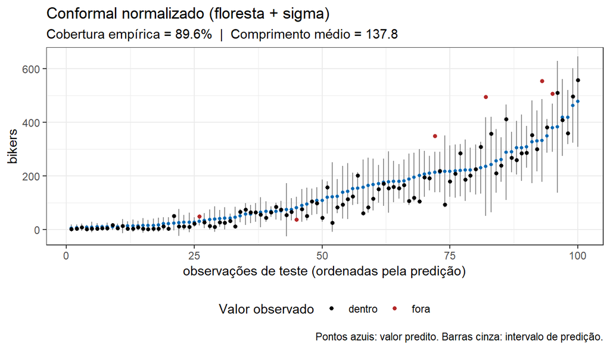

```r
grafico_intervalos(te$y, mu_te, inf_norm, sup_norm,
                   titulo = "Conformal normalizado (floresta + sigma)")
```

**Código**

```r
# Mesmo experimento da Seção 3, acrescido do conformal normalizado
experimento_norm <- function(dados, alpha) {
  sp <- dividir_dados(nrow(dados))
  tr <- dados[sp$treino, ]; ca <- dados[sp$calib, ]; te <- dados[sp$teste, ]

  lin <- lm(y ~ ., data = tr)
  rf  <- ranger(y ~ ., data = tr, num.trees = 200)
  rf_sigma <- ranger(delta ~ .,
                     data = tr |> mutate(delta = abs(y - rf$predictions)) |> select(-y),
                     num.trees = 200)

  cl <- predict(lin, newdata = te, interval = "prediction", level = 1 - alpha)

  r_lin  <- quantil_conformal(abs(ca$y - predict(lin, newdata = ca)), alpha)
  yh_lin <- predict(lin, newdata = te)

  mu_ca <- predict(rf, data = ca)$predictions
  mu_te <- predict(rf, data = te)$predictions
  r_rf  <- quantil_conformal(abs(ca$y - mu_ca), alpha)

  s_ca   <- pmax(predict(rf_sigma, data = ca)$predictions, 1e-6)
  s_te   <- pmax(predict(rf_sigma, data = te)$predictions, 1e-6)
  r_norm <- quantil_conformal(abs(ca$y - mu_ca) / s_ca, alpha)

  bind_rows(
    tibble(id = sp$teste, y = te$y, metodo = "Clássico (lm)",
           inf = cl[, "lwr"], sup = cl[, "upr"]),
    tibble(id = sp$teste, y = te$y, metodo = "Conformal (lm)",
           inf = yh_lin - r_lin, sup = yh_lin + r_lin),
    tibble(id = sp$teste, y = te$y, metodo = "Conformal (floresta)",
           inf = mu_te - r_rf, sup = mu_te + r_rf),
    tibble(id = sp$teste, y = te$y, metodo = "Conformal normalizado",
           inf = mu_te - r_norm * s_te, sup = mu_te + r_norm * s_te)
  )
}

set.seed(2026)
reps_norm <- lapply(seq_len(B), function(b) experimento_norm(dados, alpha) |> mutate(rep = b)) |>
  bind_rows() |>
  mutate(subgrupo = subgrupo[id],
         metodo = factor(metodo, levels = c("Clássico (lm)", "Conformal (lm)",
                                            "Conformal (floresta)", "Conformal normalizado")))

# Cobertura e comprimento médios globais (50 repetições)
reps_norm |>
  group_by(metodo, rep) |>
  summarise(cobertura = mean(y >= inf & y <= sup),
            comprimento = mean(sup - inf), .groups = "drop") |>
  group_by(metodo) |>
  summarise(cob_media = mean(cobertura), cob_min = min(cobertura),
            cob_max = max(cobertura), comp_medio = mean(comprimento)) |>
  knitr::kable(digits = 3, col.names = c("Método", "Cobertura média", "Mínima",
                                         "Máxima", "Comprimento médio"))
```

| Método | Cobertura média | Mínima | Máxima | Comprimento médio |
| --- | --- | --- | --- | --- |
| Clássico (lm) | 0.890 | 0.873 | 0.903 | 250.117 |
| Conformal (lm) | 0.898 | 0.877 | 0.917 | 258.969 |
| Conformal (floresta) | 0.900 | 0.882 | 0.916 | 181.209 |
| Conformal normalizado | 0.899 | 0.871 | 0.915 | 138.241 |

**Código**

```r
cob_sub_norm <- reps_norm |>
  group_by(metodo, subgrupo) |>
  summarise(cobertura = mean(y >= inf & y <= sup),
            comprimento = mean(sup - inf), .groups = "drop")

# Cobertura por subgrupo
cob_sub_norm |>
  select(-comprimento) |>
  pivot_wider(names_from = metodo, values_from = cobertura) |>
  rename(!!cfg$nome_sub := subgrupo) |>
  knitr::kable(digits = 3)
```

| Faixa horária | Clássico (lm) | Conformal (lm) | Conformal (floresta) | Conformal normalizado |
| --- | --- | --- | --- | --- |
| madrugada (0-5h) | 0.993 | 0.995 | 0.999 | 0.949 |
| dia (6-15h) | 0.843 | 0.854 | 0.869 | 0.887 |
| pico (16-19h) | 0.753 | 0.769 | 0.762 | 0.818 |
| noite (20-23h) | 0.996 | 0.997 | 0.969 | 0.935 |

**Código**

```r
# Comprimento médio por subgrupo
cob_sub_norm |>
  select(-cobertura) |>
  pivot_wider(names_from = metodo, values_from = comprimento) |>
  rename(!!cfg$nome_sub := subgrupo) |>
  knitr::kable(digits = 1)
```

| Faixa horária | Clássico (lm) | Conformal (lm) | Conformal (floresta) | Conformal normalizado |
| --- | --- | --- | --- | --- |
| madrugada (0-5h) | 250.1 | 259 | 181.2 | 50.8 |
| dia (6-15h) | 250.1 | 259 | 181.2 | 168.0 |
| pico (16-19h) | 250.1 | 259 | 181.2 | 199.4 |
| noite (20-23h) | 250.1 | 259 | 181.2 | 129.7 |

**Código**

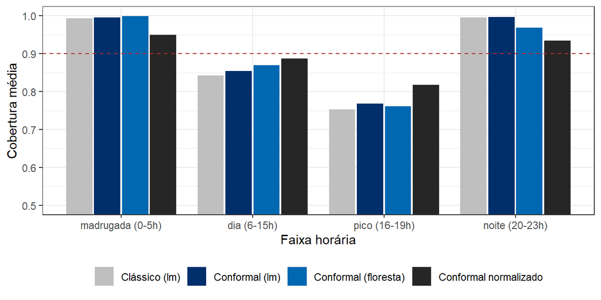

```r
ggplot(cob_sub_norm, aes(x = subgrupo, y = cobertura, fill = metodo)) +
  geom_col(position = position_dodge(width = 0.85), width = 0.8) +
  geom_hline(yintercept = 1 - alpha, linetype = 2, color = "#B42828") +
  coord_cartesian(ylim = c(0.5, 1)) +
  scale_fill_manual(values = c("grey75", "#002F6C", "#0067B1", "grey15")) +
  labs(x = cfg$nome_sub, y = "Cobertura média", fill = NULL) +
  theme_bw() +
  theme(legend.position = "bottom")
```

**Código**

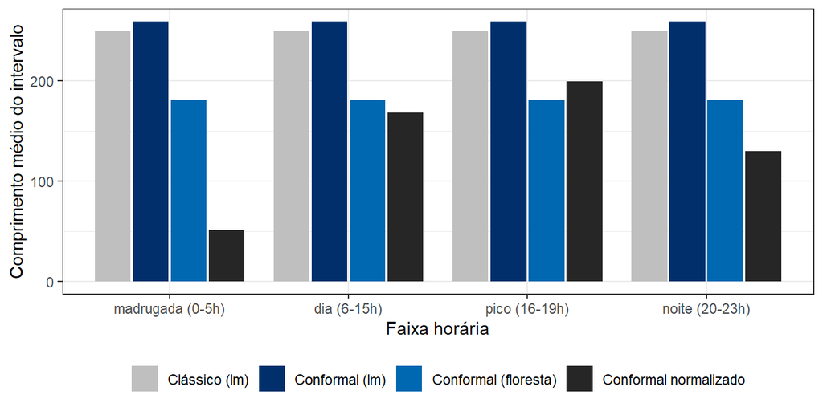

```r
ggplot(cob_sub_norm, aes(x = subgrupo, y = comprimento, fill = metodo)) +
  geom_col(position = position_dodge(width = 0.85), width = 0.8) +
  scale_fill_manual(values = c("grey75", "#002F6C", "#0067B1", "grey15")) +
  labs(x = cfg$nome_sub, y = "Comprimento médio do intervalo", fill = NULL) +
  theme_bw() +
  theme(legend.position = "bottom")
```

**Resposta:** *(a normalização melhorou a cobertura nos subgrupos? E o comprimento médio?)*

Sim, nos dois sentidos. A cobertura global continua em ~90% (a garantia marginal se mantém, pois $\hat\sigma$ foi ajustado só no treino), mas agora fica mais equilibrada entre as faixas horárias. No pico (16-19h), a cobertura subiu de ~76% para ~82%, e no dia (6-15h) de ~87% para ~89%. Na madrugada e à noite, que antes tinham cobertura excessiva (~97%-100%), ela caiu para ~95% e ~94%, mais perto dos 90%.

O ganho no comprimento é ainda maior. O comprimento médio caiu de ~181 (Conformal (floresta)) para ~138 bicicletas, cerca de 24% menor, porque o intervalo agora se adapta à variabilidade local: ~51 bicicletas na madrugada, onde a demanda é previsível, e ~199 no pico. Com isso, a “folga” que antes era desperdiçada na madrugada vai para as horas de pico.

A melhora, porém, não é completa: o pico ainda fica abaixo de 90%. O escore normalizado continua tendo apenas garantia marginal, e $\hat\sigma(x)$ é uma estimativa imperfeita da dispersão local, que parece subestimar a variabilidade justamente nas horas mais voláteis. Para garantir 90% em cada faixa horária, o passo seguinte é a calibração por subgrupo (Mondrian CP), que implementamos na Seção 8.

# 8 Extensão do grupo: Mondrian CP (calibração por faixa horária)

**DicaPor que esta seção**

Esta seção não foi pedida. A incluímos porque ela responde diretamente à limitação discutida nas Tarefas 4 e 5 e na Seção 7: com calibração única, nenhum escore garante 90% **dentro** de cada faixa horária.

Os slides citam o *Mondrian CP* (calibração por subgrupo) como um dos caminhos para a cobertura por subgrupo. A ideia é simples: em vez de um único quantil $\hat r_\alpha$, calculamos um quantil **para cada faixa horária** $g$, usando só os escores de calibração daquela faixa:
$$\hat r_\alpha^{(g)} = R^{(g)}_{(\lceil (1-\alpha)(n_g+1) \rceil)}, \qquad
C(x) = \bigl[\hat\mu(x) - \hat r_\alpha^{(g(x))},\; \hat\mu(x) + \hat r_\alpha^{(g(x))}\bigr].$$
Dentro de uma mesma faixa, os pontos de calibração e de teste continuam permutáveis, então o mesmo argumento visto em aula vale **condicionalmente à faixa**: $P\big(Y_{n+1} \in C(X_{n+1}) \mid G_{n+1} = g\big) \geq 1-\alpha$ para cada $g$. Isso só é possível porque a faixa horária é conhecida no momento da predição (é função da covariável `hr`). Usamos o mesmo $\hat\mu$ (floresta) e o mesmo escore de resíduo absoluto do Conformal (floresta); a única diferença é a calibração.

**Código**

```r
# Conformal (floresta) com calibração global vs. calibração por faixa horária
experimento_mondrian <- function(dados, alpha, grupo) {
  sp <- dividir_dados(nrow(dados))
  tr <- dados[sp$treino, ]; ca <- dados[sp$calib, ]; te <- dados[sp$teste, ]

  rf    <- ranger(y ~ ., data = tr, num.trees = 200)
  mu_ca <- predict(rf, data = ca)$predictions
  mu_te <- predict(rf, data = te)$predictions
  r_ca  <- abs(ca$y - mu_ca)

  # um quantil global e um quantil por faixa horária
  r_global <- quantil_conformal(r_ca, alpha)
  r_faixa  <- tapply(r_ca, grupo[sp$calib], quantil_conformal, alpha = alpha)
  r_te     <- r_faixa[as.character(grupo[sp$teste])]

  bind_rows(
    tibble(id = sp$teste, y = te$y, metodo = "Conformal (floresta)",
           inf = mu_te - r_global, sup = mu_te + r_global),
    tibble(id = sp$teste, y = te$y, metodo = "Mondrian (floresta)",
           inf = mu_te - r_te, sup = mu_te + r_te)
  )
}

set.seed(2026)
reps_mond <- lapply(seq_len(B), function(b)
  experimento_mondrian(dados, alpha, subgrupo) |> mutate(rep = b)) |>
  bind_rows() |>
  mutate(subgrupo = subgrupo[id])

reps_mond |>
  group_by(metodo, rep) |>
  summarise(cobertura = mean(y >= inf & y <= sup),
            comprimento = mean(sup - inf), .groups = "drop") |>
  group_by(metodo) |>
  summarise(cob_media = mean(cobertura), cob_min = min(cobertura),
            cob_max = max(cobertura), comp_medio = mean(comprimento)) |>
  knitr::kable(digits = 3, col.names = c("Método", "Cobertura média", "Mínima",
                                         "Máxima", "Comprimento médio"))
```

| Método | Cobertura média | Mínima | Máxima | Comprimento médio |
| --- | --- | --- | --- | --- |
| Conformal (floresta) | 0.903 | 0.884 | 0.924 | 182.230 |
| Mondrian (floresta) | 0.902 | 0.880 | 0.921 | 168.344 |

**Código**

```r
cob_mond <- reps_mond |>
  group_by(metodo, subgrupo) |>
  summarise(cobertura = mean(y >= inf & y <= sup),
            acima = mean(y > sup), abaixo = mean(y < inf),
            comprimento = mean(sup - inf), .groups = "drop")

cob_mond |>
  arrange(subgrupo, metodo) |>
  knitr::kable(digits = 3,
               col.names = c("Método", cfg$nome_sub, "Cobertura",
                             "Acima do limite superior", "Abaixo do limite inferior",
                             "Comprimento médio"))
```

| Método | Faixa horária | Cobertura | Acima do limite superior | Abaixo do limite inferior | Comprimento médio |
| --- | --- | --- | --- | --- | --- |
| Conformal (floresta) | madrugada (0-5h) | 0.999 | 0.001 | 0.000 | 182.236 |
| Mondrian (floresta) | madrugada (0-5h) | 0.901 | 0.033 | 0.066 | 49.433 |
| Conformal (floresta) | dia (6-15h) | 0.872 | 0.077 | 0.051 | 182.230 |
| Mondrian (floresta) | dia (6-15h) | 0.903 | 0.064 | 0.033 | 204.013 |
| Conformal (floresta) | pico (16-19h) | 0.771 | 0.203 | 0.026 | 182.225 |
| Mondrian (floresta) | pico (16-19h) | 0.904 | 0.091 | 0.005 | 285.745 |
| Conformal (floresta) | noite (20-23h) | 0.970 | 0.002 | 0.028 | 182.224 |
| Mondrian (floresta) | noite (20-23h) | 0.900 | 0.006 | 0.094 | 133.448 |

**Código**

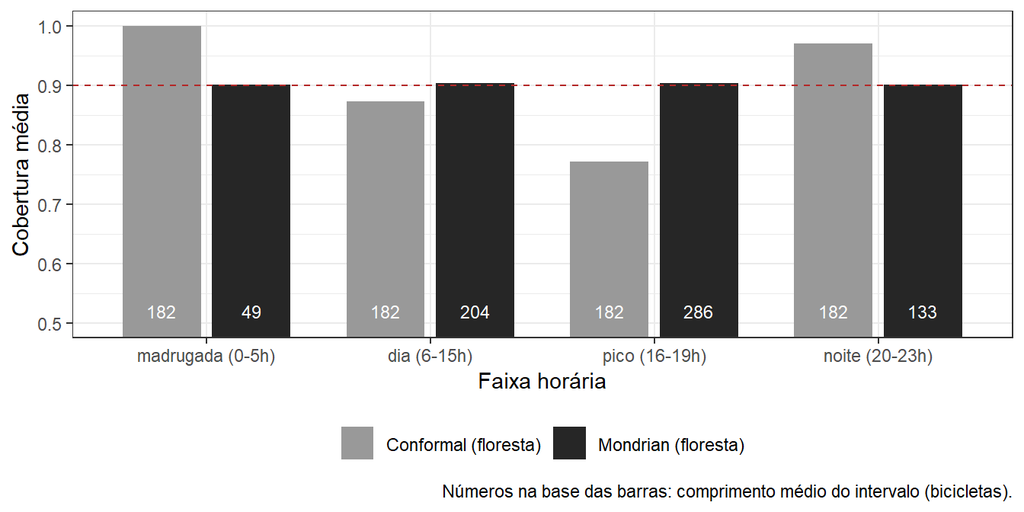

```r
ggplot(cob_mond, aes(x = subgrupo, y = cobertura, fill = metodo)) +
  geom_col(position = position_dodge(width = 0.8), width = 0.7) +
  geom_hline(yintercept = 1 - alpha, linetype = 2, color = "#B42828") +
  geom_text(aes(label = sprintf("%.0f", comprimento), y = 0.52),
            position = position_dodge(width = 0.8), size = 3, color = "white") +
  coord_cartesian(ylim = c(0.5, 1)) +
  scale_fill_manual(values = c("grey60", "grey15")) +
  labs(x = cfg$nome_sub, y = "Cobertura média", fill = NULL,
       caption = "Números na base das barras: comprimento médio do intervalo (bicicletas).") +
  theme_bw() +
  theme(legend.position = "bottom")
```

**Resultado:** com a mesma floresta e o mesmo escore, calibrar por faixa horária leva a cobertura a ~90% em **todas** as faixas (madrugada, dia, pico e noite), contra 77% a 100% na calibração global, e a cobertura global continua em ~90%. Em vez de um comprimento único de ~182 bicicletas, cada faixa recebe a largura de que precisa: ~49 na madrugada e ~286 no pico. Como resultado, o comprimento médio **cai** para ~168: o que se economiza nas horas previsíveis compensa o alargamento no pico.

Na comparação com o escore normalizado (Seção 7), o Mondrian corrige a cobertura por faixa com garantia teórica, mas não se adapta **dentro** da faixa (todas as horas de pico recebem a mesma largura). O normalizado se adapta a cada $x$, mas só tem garantia marginal. O custo do Mondrian é usar menos pontos de calibração por quantil (~440 no pico, em vez de ~2.600), o que deixa $\hat r^{(g)}_\alpha$ mais variável; aqui isso não é problema, mas com subgrupos pequenos seria. Além disso, os subgrupos precisam ser definidos **antes** de olhar os resultados do teste. As duas ideias também podem ser combinadas (escore normalizado calibrado por faixa).

# Reprodutibilidade

O `.qmd` e o `.html` desta atividade estão versionados no repositório https://github.com/ArthurGoon/lea-predicao-conformal. Para reproduzir, basta instalar os pacotes listados nas instruções e renderizar o arquivo; todas as etapas aleatórias usam sementes fixas (`set.seed`), então os resultados são idênticos aos apresentados aqui.

**Código**